# Chapter 6

Let us start the sixth week assignment by loading the datasets to be used in this weeks assignments. Note that as we have prepared the data, we have also saved it in RDS-format (as opposed to a, say, csv-file) in order for all the features of the data to be preserved (namely, categorical variables stay as factors).

```r
BPRSL <- readRDS("data/BPRSL.rds")
RATSL <- readRDS("data/RATSL.rds")
```

## RATS

In the first half of this week’s analysis we shall replicate the analysis from Chapter 8 of *Multivariate Analysis for the Behavioral Sciences* (MABS), but using the `RATS` data (which we have loaded in long format above). The data consists of repeated measurements of weights of 16 individual rats which are further divided into 3 different groups with different diets.

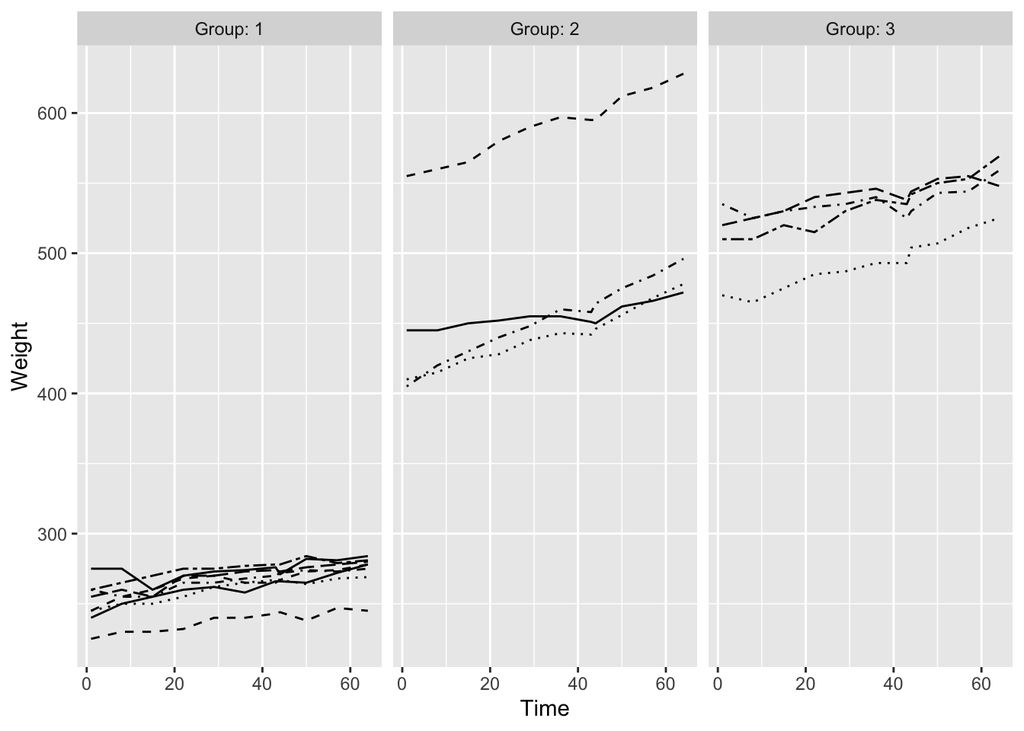

```r
ggplot(RATSL, aes(x = Time, y = Weight, linetype = ID)) +
  geom_line() +
  scale_linetype_manual(values = rep(1:10, times = 4)) +
  facet_grid(. ~ Group, labeller = label_both) +
  theme(legend.position = "none")
```

Evidently, weights of the rats in group one are much less to begin with than those of in the other two groups. Also, rats in the last group are heavier than those in the second group, apart from one specific rat in the second group that is the heaviest of them all, and is the only one with weight greatly differing from the other rats in the same group. The figure above also clearly depicts that in general the rats have gained weight over the time of the study, some slightly more than others.

The rats with more initial weight tend to be obviously heavier throughout the study (phenomenon known as *tracking*), making the visual assessment of any treatment effects between groups quite difficult. To this end, we may standardize the data before plotting. That is, in the figure below we have standardized the rats weights to have zero mean and unit standard deviation within each group.

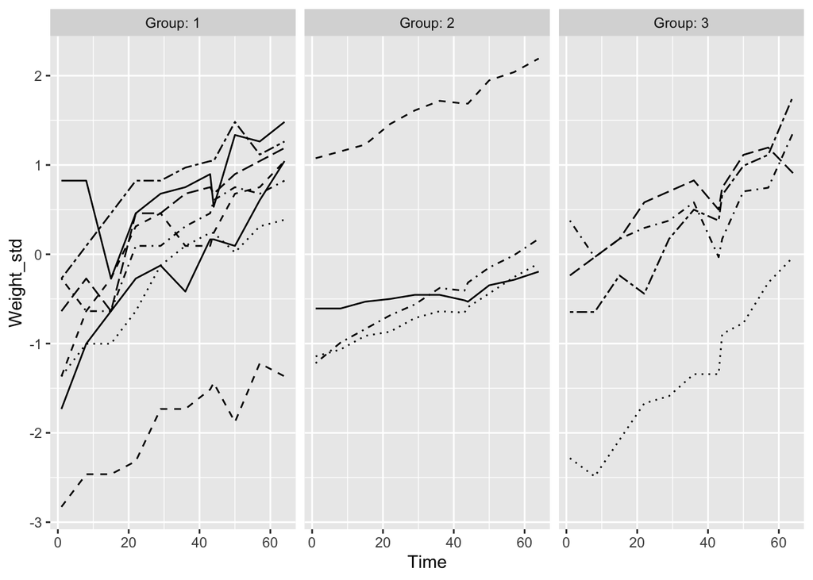

```r
# Standardise the weights within groups
RATSL <- RATSL %>%
  group_by(Group) %>%
  mutate(Weight_std = (Weight - mean(Weight))/sd(Weight) ) %>%
  ungroup()

# Replot, but with standardized weights
ggplot(RATSL, aes(x = Time, y = Weight_std, linetype = ID)) +
  geom_line() +
  scale_linetype_manual(values = rep(1:10, times = 4)) +
  facet_grid(. ~ Group, labeller = label_both) +
  theme(legend.position = "none")
```

According to the plot with standardized data, the treatment effect (the weight gained throughout the study) seems slightly smaller for rats in the second group compared to the other two groups. However, the standardizing has also made it clear that there are actually one relatively distinct individual (outlier) in each group, which might have an effect on standardization.

Perhaps plotting the within groups means would help in our visual assessment? As there is however a clear difference in the initial values between the groups, even better idea is to plot mean profiles of weight gained within groups with the associated standard errors.

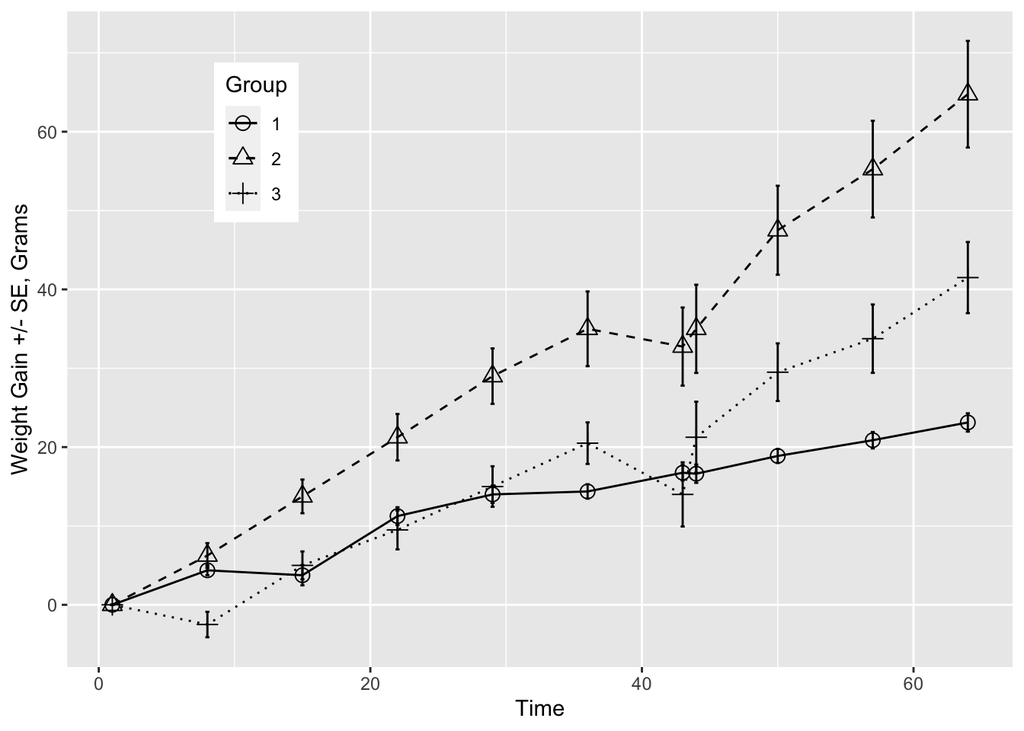

```r
# Add variable 'Weight_gain'
RATSL$Weight_gain <- NA
Weight_init <- RATSL$Weight[which(RATSL$Time == 1)]
for(i in levels(as.factor(RATSL$Time))) {
  rows <- which(RATSL$Time == as.numeric(i))
  RATSL$Weight_gain[rows] <- RATSL$Weight[rows] - Weight_init
}

# Summary data with mean and standard error of Weight_gain by Group and Time
RATSL2 <- RATSL %>%
  group_by(Group, Time) %>%
  summarise(mean_gain = mean(Weight_gain), se = sd(Weight_gain) / length(Weight_gain)) %>%
  ungroup() %>%
  group_by(Group)

# Plot the weight gain mean profiles
ggplot(RATSL2, aes(x = Time, y = mean_gain, linetype = Group, shape = Group)) +
  geom_line() +
  scale_linetype_manual(values = c(1, 2, 3)) +
  geom_point(size = 3) +
  geom_errorbar(aes(ymin = mean_gain - se, ymax = mean_gain + se, linetype = "1"), width = 0.3) +
  scale_shape_manual(values = c(1, 2, 3)) +
  theme(legend.position = c(0.2, 0.8)) +
  scale_y_continuous(name = "Weight Gain +/- SE, Grams") +
  scale_x_continuous(name = "Time")
```

Finally, we are starting to get a clearer picture of what is going on between the groups. The rats in the second group have gained the most weight on average, while the rats from the first group have gained the least. However, we are looking at the actual weight gained in grams here and the relative weight gain in percentages might tell a different story, with respect to the first group at least. To that end let us quickly plot such a figure as well.

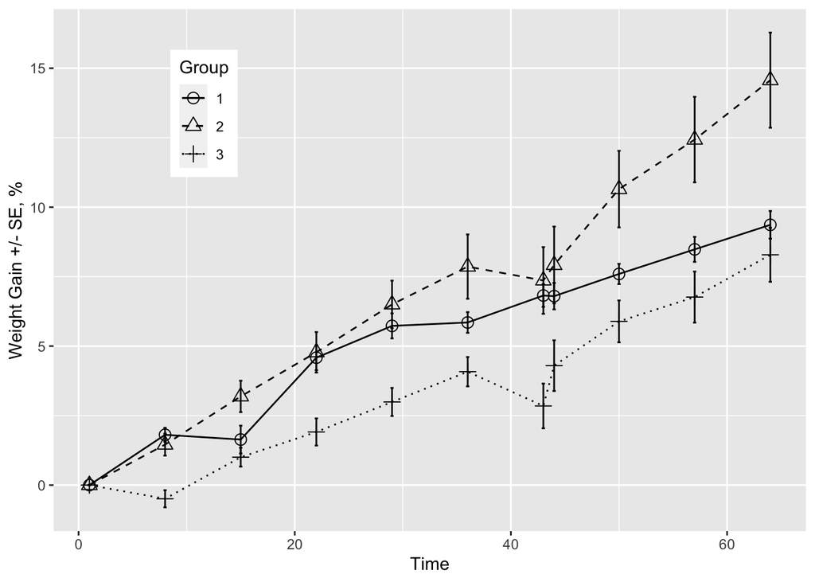

```r
# Add variable 'Weight_rel_gain'
RATSL$Weight_rel_gain <- NA
Weight_init <- RATSL$Weight[which(RATSL$Time == 1)]
for(i in levels(as.factor(RATSL$Time))) {
  rows <- which(RATSL$Time == as.numeric(i))
  RATSL$Weight_rel_gain[rows] <- 100 * ((RATSL$Weight[rows] - Weight_init) / Weight_init)
}

# Summary data with mean and standard error of Weight_gain by Group and Time
RATSL3 <- RATSL %>%
  group_by(Group, Time) %>%
  summarise(mean_rel_gain = mean(Weight_rel_gain), se = sd(Weight_rel_gain) / length(Weight_rel_gain)) %>%
  ungroup() %>%
  group_by(Group)

# Plot the weight gain mean profiles
ggplot(RATSL3, aes(x = Time, y = mean_rel_gain, linetype = Group, shape = Group)) +
  geom_line() +
  scale_linetype_manual(values = c(1, 2, 3)) +
  geom_point(size = 3) +
  geom_errorbar(aes(ymin = mean_rel_gain - se, ymax = mean_rel_gain + se, linetype = "1"), width = 0.3) +
  scale_shape_manual(values = c(1, 2, 3)) +
  theme(legend.position = c(0.2, 0.8)) +
  scale_y_continuous(name = "Weight Gain +/- SE, %") +
  scale_x_continuous(name = "Time")
```

Indeed, if we look at the relative weight gained, the eventual mean weights in the first and third group are not statistically different from each other anymore. We may treat the the percentage-wise difference in weight gained throughout the study as our outcome of interest. To that end, let us take a closer look at the eventual relative weight gain by plotting a box plot of those values.

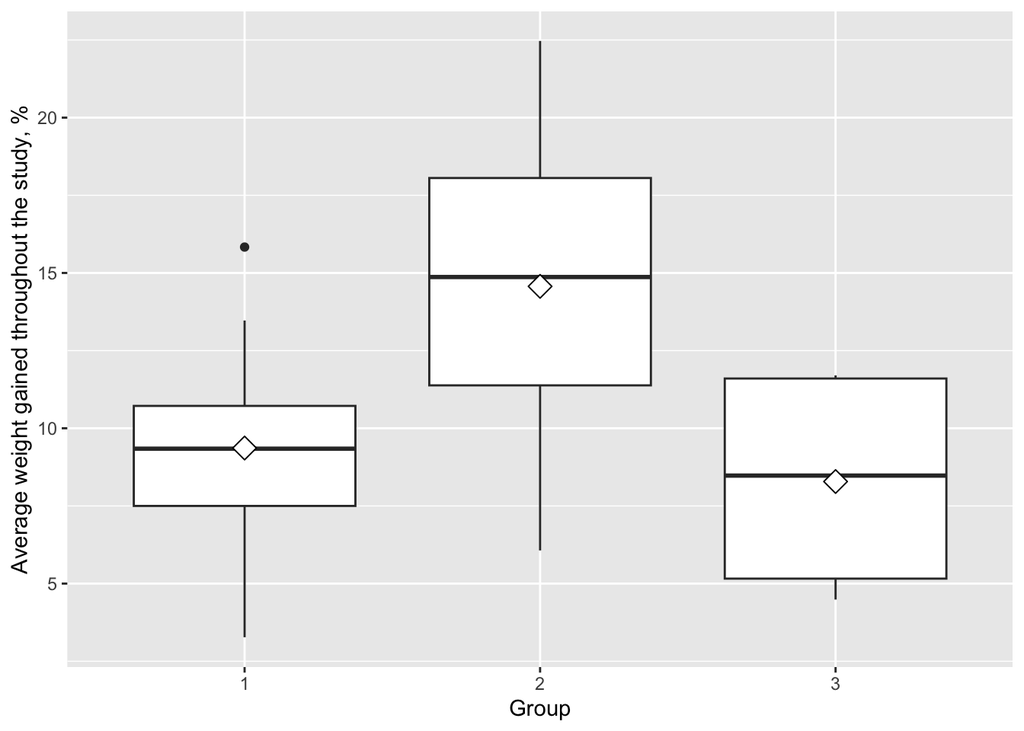

```r
# Create another summary data for the boxplot
RATSL4 <- RATSL %>%
  filter(Time == max(Time)) %>%
  group_by(Group, ID) %>%
  summarise(mean = mean(Weight_rel_gain)) %>%
  ungroup()

# Draw a boxplot of the outcome of interest versus the group (or treatment)
ggplot(RATSL4, aes(x = Group, y = mean)) +
  geom_boxplot() +
  stat_summary(fun = "mean", geom = "point", shape = 23, size = 4, fill = "white") +
  scale_y_continuous(name = "Average weight gained throughout the study, %")
```

The boxplot tells us pretty much the same story as the previous plot. Although there is plenty of variability within the groups, the rats in the second group have gained clearly more weight than the two other groups. There is also more variability in the last than in the first group, but the average gain is more or less much the same between those groups. Also, first group seems to feature a bit of an outlier, with one rat gaining somewhat more weight than the other rats within that group. However, nothing suggests that that individual not to be representative of the population of interest and we should **not** drop this individual from the data (the observation is actually within two standard deviations from the mean, hence not even much of an outlier).

We may finally take a more formal approach to what is implied by our earlier visual assessments, that is has the second group really has gained more weight, by running pairwise t-tests between the groups.

```r
groups <- list()
for(i in 1:3) groups[[i]] <- RATSL4$mean[which(RATSL4$Group == i)]
t.test(groups[[1]], groups[[2]])
```

```
##
##  Welch Two Sample t-test
##
## data:  groups[[1]] and groups[[2]]
## t = -1.4056, df = 4.0499, p-value = 0.2317
## alternative hypothesis: true difference in means is not equal to 0
## 95 percent confidence interval:
##  -15.436270   5.026318
## sample estimates:
## mean of x mean of y
##  9.363791 14.568768
```

```r
t.test(groups[[1]], groups[[3]])
```

```
##
##  Welch Two Sample t-test
##
## data:  groups[[1]] and groups[[3]]
## t = 0.44946, df = 6.2398, p-value = 0.6683
## alternative hypothesis: true difference in means is not equal to 0
## 95 percent confidence interval:
##  -4.738523  6.895430
## sample estimates:
## mean of x mean of y
##  9.363791  8.285338
```

```r
t.test(groups[[2]], groups[[3]])
```

```
##
##  Welch Two Sample t-test
##
## data:  groups[[2]] and groups[[3]]
## t = 1.5957, df = 4.7498, p-value = 0.1745
## alternative hypothesis: true difference in means is not equal to 0
## 95 percent confidence interval:
##  -4.00114 16.56800
## sample estimates:
## mean of x mean of y
## 14.568768  8.285338
```

It turns out that although the differences in means are apparent, the differences are not statistically significant with any commonly used confidence levels. P-values for tests for difference in means between the second group against the two other groups are however clearly smaller than of the test between the first and third group, as expected. The lack of statistical significant is however no surprise, since we have so few observations, with only 8, 4 and 4 individuals in each group, respectively.

## BPRS

In the another half of this week’s analysis we shall replicate the analysis from Chapter 9 of *Multivariate Analysis for the Behavioral Sciences* (MABS), only this time using the `BPRS` data (which we have also loaded in long format at the beginning of this chapter). The data consists of repeated measurements of 40 male subjects that were assigned randomly to one of two treatment groups. Each subject was rated weekly on the brief psychiatric rating scale (BPRS) for eight weeks and once before the treatment began. The BPRS assesses different symptoms on a scale from one to seven and is used to evaluate patients suspected of having schizophrenia.

Let us begin the analysis by plotting the data.

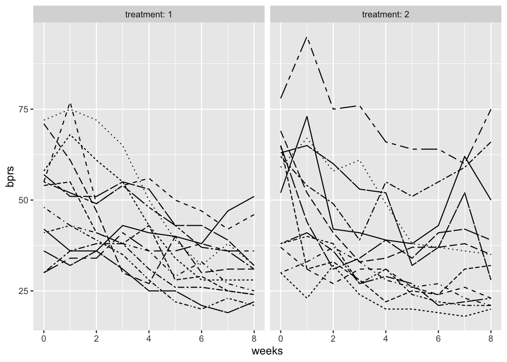

```r
ggplot(BPRSL, aes(x = weeks, y = bprs, linetype = subject)) +
  geom_line() +
  facet_grid(. ~ treatment, labeller = label_both) +
  theme(legend.position = "none")
```

By first impression there seems to be a modest downward trend in BPRS for both treatments over the course of the study, suggesting the treatments to be somewhat successful. There however seems to be more dispersion, or heterogeneity in responses to the treatment, in the second group than in the first, suggesting the first treatment to perhaps have a more uniform effect.

Visual assessment however gets us only so far and in what follows we shall take a more formal approach to our analysis. We shall start with a naive linear regression model and ignore the serial correlation of the observations for now. We use BPRS as the dependent variables and both the time (weeks) and the treatment group (binary) as explanatory variables.

```r
# Linear regression model
BPRS_lm <- lm(bprs ~ weeks + treatment, data = BPRSL)

# Print out a summary of the model
summary(BPRS_lm)
```

```
##
## Call:
## lm(formula = bprs ~ weeks + treatment, data = BPRSL)
##
## Residuals:
##     Min      1Q  Median      3Q     Max
## -22.454  -8.965  -3.196   7.002  50.244
##
## Coefficients:
##             Estimate Std. Error t value Pr(>|t|)
## (Intercept)  46.4539     1.3670  33.982   <2e-16 ***
## weeks        -2.2704     0.2524  -8.995   <2e-16 ***
## treatment2    0.5722     1.3034   0.439    0.661
## ---
## Signif. codes:  0 '***' 0.001 '**' 0.01 '*' 0.05 '.' 0.1 ' ' 1
##
## Residual standard error: 12.37 on 357 degrees of freedom
## Multiple R-squared:  0.1851, Adjusted R-squared:  0.1806
## F-statistic: 40.55 on 2 and 357 DF,  p-value: < 2.2e-16
```

The results of the linear regression model are summarized above. Evidently, there is a statistically clearly significant downward sloping time trend, which can be interpreted as the BPRS to be around 2.3 points lower every week on average. There is however no statistically significant difference in overall level of BPRS between two treatment groups. This is however by no means an optimal model to use. First, the observations are by no means independent (although conditional on the time trend they could be, under further assumptions). Second, our interest lies in the difference of the treatment effect between two groups, which we could interpret for example as different slope parameters for two groups. However, above we have assumed the groups to share the slope parameter, but have different intercept, which doesn’t seem ideal given the circumstances. Moreover, different subjects have different initial scores, suggesting that individuals might have different intercepts as well.

To the latter end, let us next fit a random intercept model in which all the subjects have their own “random” intercept that follows a normal distribution.

```r
# Random intercept model
BPRS_lme1 <- lmer(bprs ~ weeks + treatment + (1 | subject), data = BPRSL, REML = FALSE)

# Print out a summary of the model
summary(BPRS_lme1)
```

```
## Linear mixed model fit by maximum likelihood  ['lmerMod']
## Formula: bprs ~ weeks + treatment + (1 | subject)
##    Data: BPRSL
##
##      AIC      BIC   logLik deviance df.resid
##   2748.7   2768.1  -1369.4   2738.7      355
##
## Scaled residuals:
##     Min      1Q  Median      3Q     Max
## -3.0481 -0.6749 -0.1361  0.4813  3.4855
##
## Random effects:
##  Groups   Name        Variance Std.Dev.
##  subject  (Intercept)  47.41    6.885
##  Residual             104.21   10.208
## Number of obs: 360, groups:  subject, 20
##
## Fixed effects:
##             Estimate Std. Error t value
## (Intercept)  46.4539     1.9090  24.334
## weeks        -2.2704     0.2084 -10.896
## treatment2    0.5722     1.0761   0.532
##
## Correlation of Fixed Effects:
##            (Intr) weeks
## weeks      -0.437
## treatment2 -0.282  0.000
```

The point estimates for the parameters of interest stay the same for the random intercept model as for the naive linear regression model (as they should), but letting the intercepts between subjects vary might give us smaller parameter variance (if our random intercept assumption fits the data) and potentially statistically significant results. As expected, this is however not the case here. Parameter variance, or standard errors, do get indeed smaller, but not by much and the treatments do not still differ statistically significantly from another.

Next, let us fit a model with both random intercept and slope parameters. That is, in addition to the intercept, we let the slope parameter to vary between individuals as well.

```r
# Random intercept and random slope model
BPRS_lme2 <- lmer(bprs ~ weeks + treatment + (weeks | subject), data = BPRSL, REML = FALSE)

# Print out a summary of the model
summary(BPRS_lme2)
```

```
## Linear mixed model fit by maximum likelihood  ['lmerMod']
## Formula: bprs ~ weeks + treatment + (weeks | subject)
##    Data: BPRSL
##
##      AIC      BIC   logLik deviance df.resid
##   2745.4   2772.6  -1365.7   2731.4      353
##
## Scaled residuals:
##     Min      1Q  Median      3Q     Max
## -2.8919 -0.6194 -0.0691  0.5531  3.7976
##
## Random effects:
##  Groups   Name        Variance Std.Dev. Corr
##  subject  (Intercept) 64.8222  8.0512
##           weeks        0.9609  0.9802   -0.51
##  Residual             97.4305  9.8707
## Number of obs: 360, groups:  subject, 20
##
## Fixed effects:
##             Estimate Std. Error t value
## (Intercept)  46.4539     2.1052  22.066
## weeks        -2.2704     0.2977  -7.626
## treatment2    0.5722     1.0405   0.550
##
## Correlation of Fixed Effects:
##            (Intr) weeks
## weeks      -0.582
## treatment2 -0.247  0.000
```

To our disappointment, the results do not however change much. There are no significant differences between the results of our last two models. We might still be interested in knowing which one better fits the data, that is results of which model should we report or continue working with? To this end we may take a look of log-likelihoods of the models and the associated likelihood ratio test.

```r
# ANOVA test on the two models
anova(BPRS_lme1, BPRS_lme2)
```

```
## Data: BPRSL
## Models:
## BPRS_lme1: bprs ~ weeks + treatment + (1 | subject)
## BPRS_lme2: bprs ~ weeks + treatment + (weeks | subject)
##           npar    AIC    BIC  logLik deviance  Chisq Df Pr(>Chisq)
## BPRS_lme1    5 2748.7 2768.1 -1369.4   2738.7
## BPRS_lme2    7 2745.4 2772.6 -1365.7   2731.4 7.2721  2    0.02636 *
## ---
## Signif. codes:  0 '***' 0.001 '**' 0.01 '*' 0.05 '.' 0.1 ' ' 1
```

The latter model seems to have slightly higher log-likelihood and likelihood ratio test indeed suggests the difference to be statistically significant on a 5% level (but not on a, say, 1% level).

Finally we will fit a model that, in addition to everything else, allows for time and group interactions. In practice, this way we may facilitate our earlier discussed hypothesis of different slopes between the groups.

```r
# Random intercept and random slope model with time x group interactions
BPRS_lme3 <- lmer(bprs ~ weeks + treatment + (weeks | subject) + weeks * treatment, data = BPRSL, REML = FALSE)

# Print out a summary of the model
summary(BPRS_lme3)
```

```
## Linear mixed model fit by maximum likelihood  ['lmerMod']
## Formula: bprs ~ weeks + treatment + (weeks | subject) + weeks * treatment
##    Data: BPRSL
##
##      AIC      BIC   logLik deviance df.resid
##   2744.3   2775.4  -1364.1   2728.3      352
##
## Scaled residuals:
##     Min      1Q  Median      3Q     Max
## -3.0512 -0.6271 -0.0768  0.5288  3.9260
##
## Random effects:
##  Groups   Name        Variance Std.Dev. Corr
##  subject  (Intercept) 64.9964  8.0620
##           weeks        0.9687  0.9842   -0.51
##  Residual             96.4707  9.8220
## Number of obs: 360, groups:  subject, 20
##
## Fixed effects:
##                  Estimate Std. Error t value
## (Intercept)       47.8856     2.2521  21.262
## weeks             -2.6283     0.3589  -7.323
## treatment2        -2.2911     1.9090  -1.200
## weeks:treatment2   0.7158     0.4010   1.785
##
## Correlation of Fixed Effects:
##             (Intr) weeks  trtmn2
## weeks       -0.650
## treatment2  -0.424  0.469
## wks:trtmnt2  0.356 -0.559 -0.840
```

Now, according to the model with interactions the slope parameter is indeed greater in absolute value for the first treatment group, which indeed matches our earlier visual assessment. Still, the difference is only barely, or not at all, statistically significant. Computation of exact p-values for linear mixed models is not trivial, nor is it always recommended, but the t-score for the interaction term is 1.785, hence for instance approximate 95% confidence would include zero, while 90% confidence interval would not. We conclude our model thus to provide tentative support in favor of the first treatment over the second. More importantly, the effect of both treatments is statistically different from zero as indicated by the high absolute t-score for the slope.

Actually, the likelihood ratio test (below) suggests our latter model to fit the data only slightly better than the previous one, the difference being statistically significant, again, only on a 90% level, but not on the commonly used 95% level. This further corroborates the fact that we should definitely be cautious with our conclusions and most probably more data is needed to make anything but very tentative conclusion regarding the differences in success between the two treatments.

```r
# ANOVA test on models with and without interactions
anova(BPRS_lme2, BPRS_lme3)
```

```
## Data: BPRSL
## Models:
## BPRS_lme2: bprs ~ weeks + treatment + (weeks | subject)
## BPRS_lme3: bprs ~ weeks + treatment + (weeks | subject) + weeks * treatment
##           npar    AIC    BIC  logLik deviance  Chisq Df Pr(>Chisq)
## BPRS_lme2    7 2745.4 2772.6 -1365.7   2731.4
## BPRS_lme3    8 2744.3 2775.4 -1364.1   2728.3 3.1712  1    0.07495 .
## ---
## Signif. codes:  0 '***' 0.001 '**' 0.01 '*' 0.05 '.' 0.1 ' ' 1
```

Last but not the least, let us plot the fitted values of the last model against the observed data to get some idea of how well the model actually fits the data (in absolute terms, that is not against some other model). Below the observed values are in red and the fitted values in blue. Clearly the model provides reasonable approximation for the first treatment group, but the model does not account for heteroskedasticity in different groups (that is different variance in different groups). For this reason, the fitted values for the second treatment group seem to be too tightly packed and some subjects fall way outside this pack of fitted values. To conclude there is still some room for improvement, but for now we leave our analysis here.

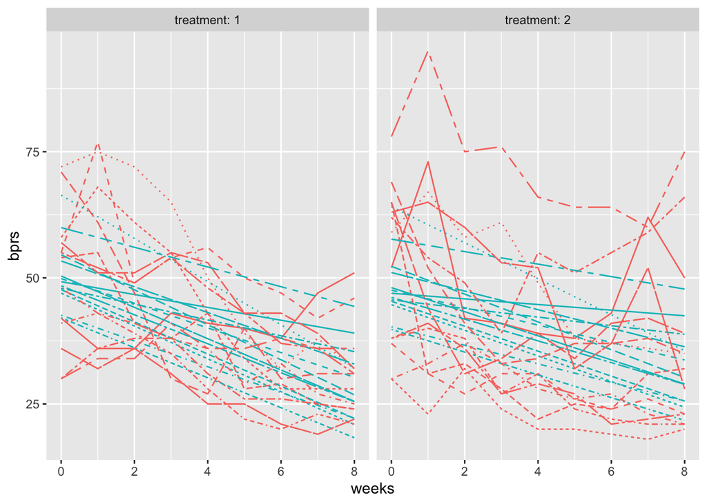

```r
# Create a new data with fitted values of BPRSL instead of observed
BPRSL_fitted <- BPRSL
BPRSL_fitted$bprs <- predict(BPRS_lme3)

# Combine the data with observed and fitted values and add new column fitted
BPRSL$fitted <- 0
BPRSL_fitted$fitted <- 1
BPRSL_combined <- rbind(BPRSL, BPRSL_fitted)
BPRSL_combined$fitted <- as.factor(BPRSL_combined$fitted)

# Plot the observed values against the fitted values
ggplot(BPRSL_combined) +
  geom_line(aes(x = weeks, y = bprs, linetype = subject, col = fitted)) +
  facet_grid(. ~ treatment, labeller = label_both) +
  theme(legend.position = "none")
```

I suppose this concludes the last assignment of this course. I hope you had a nice course, whoever you are, and I wish you happy holidays!

[figure not shown]